# GBI6 - BIOINFORMÁTICA

### [0.5 PUNTOS] 2.2 Utilizando la función `lapply()` genera la lista `cancertype_boxplots` con las gráficas para cada tipo de cancer (cada tipo de dataset).

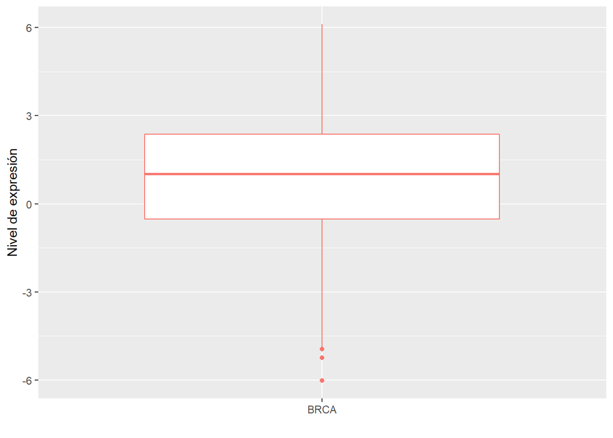

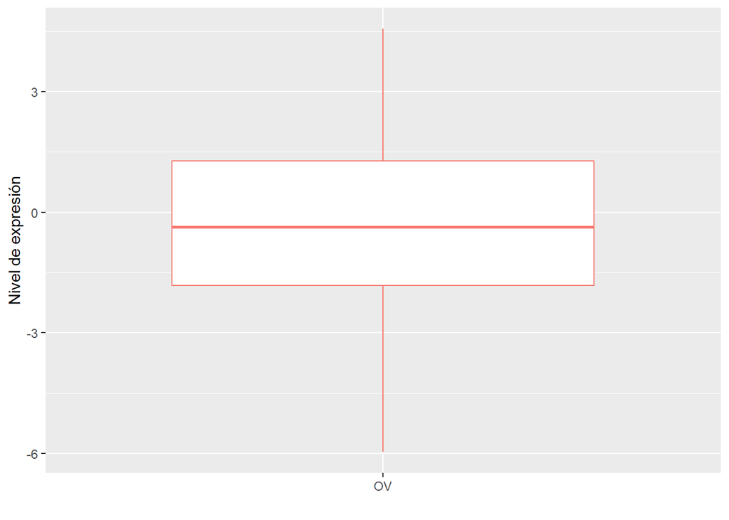

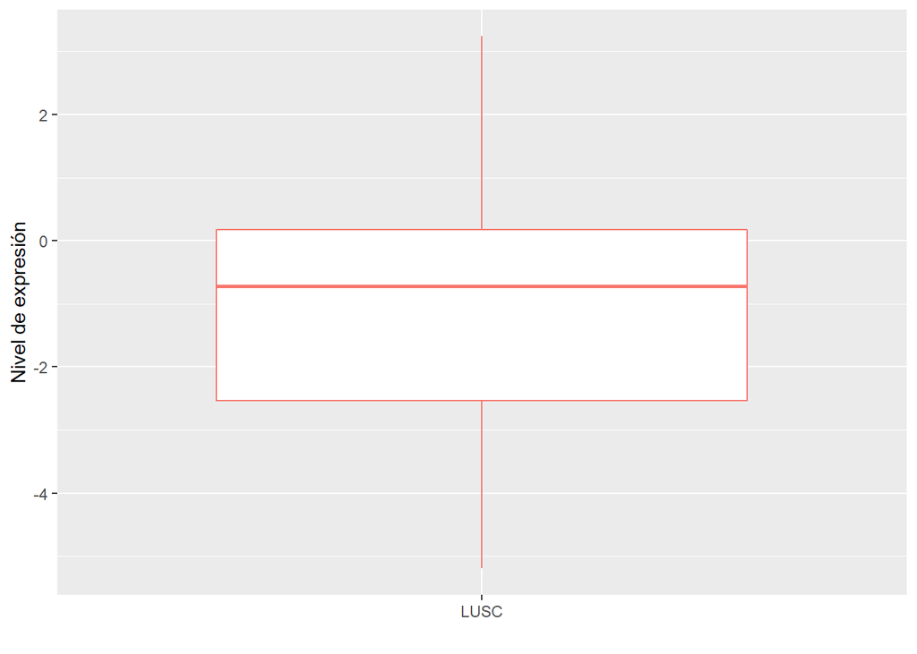

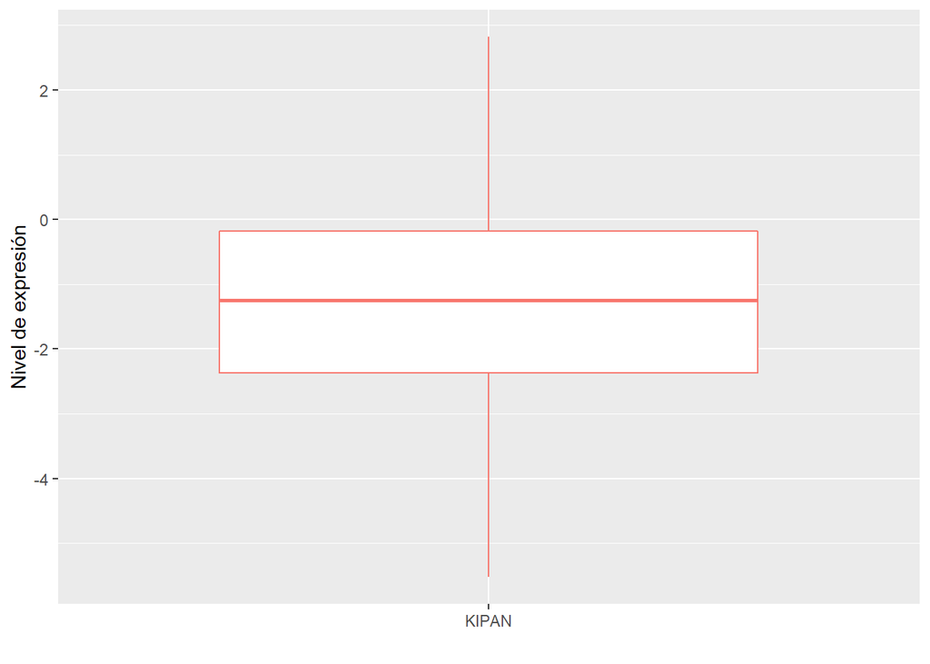

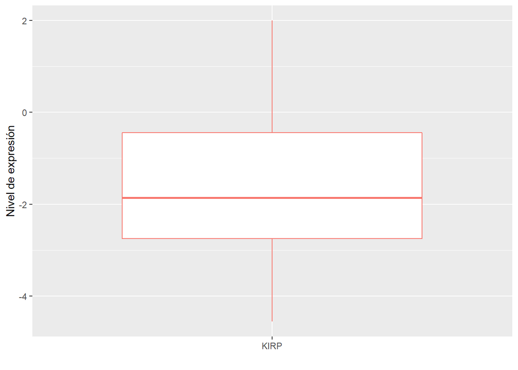

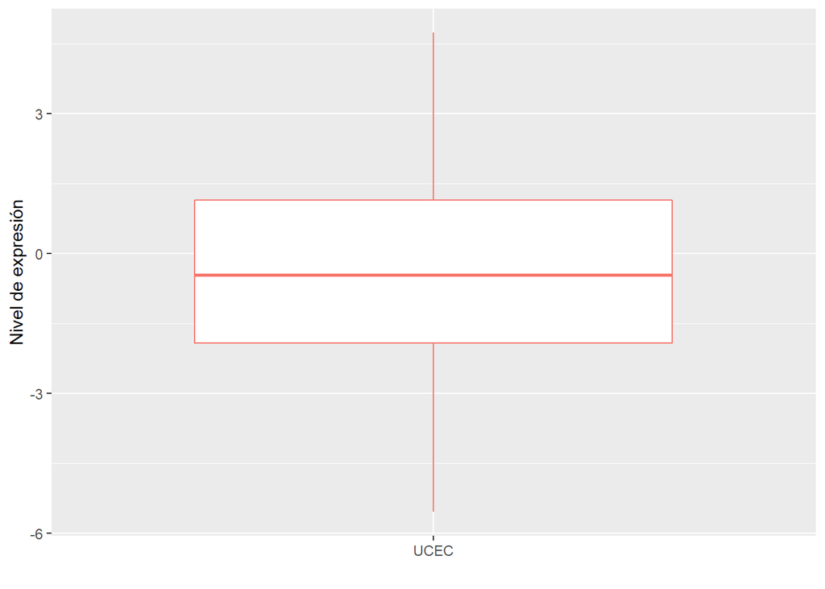

```r
# Escriba el código para generar la lista.

cancertipos <- list(
  BRCA <- filter(df_long, dataset == "BRCA"),
  OV <- filter(df_long, dataset == "OV"),
  LUSC <- filter(df_long, dataset == "LUSC"),
  KIPAN <- filter(df_long, dataset == "KIPAN"),
  KIRP <- filter(df_long, dataset == "KIRP"),
  UCEC <- filter(df_long, dataset == "UCEC")
)

cancertiposbox = lapply(cancertipos, function(x) {ggplot(x, aes(dataset, expresion_level, col = dataset)) +
    geom_boxplot() + theme(legend.position='none') + labs(x = "", y = "Nivel de expresión")})

cancertiposbox
```

### [0.5 PUNTOS] 2.3 Guarde en el subdirectorio `result` el tercer plot de la lista `cancertype_boxplots` con el nombre `boxplot3.png`. La definición de a figura debe ser de 300dpi.

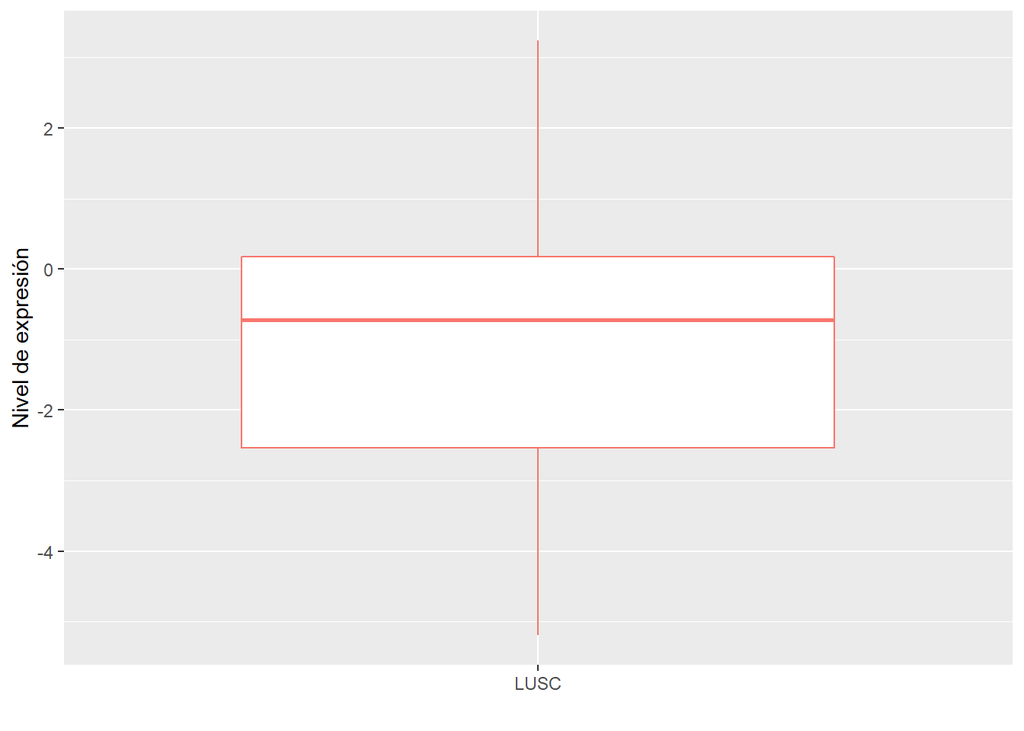

```r
# Escriba el código para guardar la tercera figura de la lista.
cancertiposbox[3]
```

```r
ggsave("C:/Users/MISHELLE/Desktop/GBI6_ExamenFinal/GBI6_ExamenFinal/results/boxplot3.png", width = 6, height = 8, dpi = 300)
```

### [1 PUNTO] 2.4 Escriba la función `reg_gen_expression`, con el parámetro `gen`. En este caso la función visualizará una gráfica de nube de puntos (geom_point) y una regresión por tipo de “dataset”. La gráfica será de comparación de gen1 con gen2; por ejemplo en el eje “x” `GATA3` y en el eje “y”” `FN1`.

```r
# Escriba aquí su función reg_gen_expression

datatipos <- list(BRCA <- filter(df_long, dataset == "BRCA"), OV <- filter(df_long, dataset == "OV"),
    LUSC <- filter(df_long, dataset == "LUSC"),
    KIPAN <- filter(df_long, dataset == "KIPAN"),
    KIRP <- filter(df_long, dataset == "KIRP"),
    UCEC <- filter(df_long, dataset == "UCEC"),
    GAPDH <- filter(df_long, dataset == "GAPDH")
  )

cancerplot <- list (
  BRCA_1 <- BRCA %>% group_by(gen) %>% mutate(row = row_number()) %>%
    tidyr::pivot_wider(names_from = gen, values_from = expresion_level) %>%
    select(-row),
  OV_1 <- OV %>% group_by(gen) %>% mutate(row = row_number()) %>%
    tidyr::pivot_wider(names_from = gen, values_from = expresion_level) %>%
    select(-row),
  LUSC_1 <- LUSC %>% group_by(gen) %>% mutate(row = row_number()) %>%
    tidyr::pivot_wider(names_from = gen, values_from = expresion_level) %>%
    select(-row),
  KIPAN_1 <- KIPAN %>% group_by(gen) %>% mutate(row = row_number()) %>%
    tidyr::pivot_wider(names_from = gen, values_from = expresion_level) %>%
    select(-row),
  KIRP_1 <- KIRP %>% group_by(gen) %>% mutate(row = row_number()) %>%
    tidyr::pivot_wider(names_from = gen, values_from = expresion_level) %>%
    select(-row),
  UCEC_1 <- UCEC %>% group_by(gen) %>% mutate(row = row_number()) %>%
    tidyr::pivot_wider(names_from = gen, values_from = expresion_level) %>%
    select(-row),
  GAPH_1 <- UCEC %>% group_by(gen) %>% mutate(row = row_number()) %>%
    tidyr::pivot_wider(names_from = gen, values_from = expresion_level) %>%
    select(-row)
)
```

### [0.5 PUNTOS] 2.5. Utilizando la función `lapply()` genera la lista `reg_genplots` con las gráficas para cada par de genes posibles. Recuerde que tiene 7 tipos de genes, se debe tener todas las combinaciones posibles por pares de genes (combinatoria sin repetición).

```r
# Escriba el código para generar la lista.
expresion_gen_reg <- function (gen) {
  if (gen == "GATA3"){
    total <- list (
      lapply(cancerplot, function(x) {ggplot(x, aes(GATA3, PTEN)) +
          geom_point() + geom_smooth(method='lm', formula= y~x)}),
      lapply(cancerplot, function(x) {ggplot(x, aes(GATA3, XBP1)) +
          geom_point() + geom_smooth(method='lm', formula= y~x)}),
      lapply(cancerplot, function(x) {ggplot(x, aes(GATA3, ESR1)) +
          geom_point() + geom_smooth(method='lm', formula= y~x)}),
      lapply(cancerplot, function(x) {ggplot(x, aes(GATA3, MUC1)) +
          geom_point() + geom_smooth(method='lm', formula= y~x)}),
      lapply(cancerplot, function(x) {ggplot(x, aes(GATA3, FN1)) +
          geom_point() + geom_smooth(method='lm', formula= y~x)}),
      lapply(cancerplot, function(x) {ggplot(x, aes(GATA3, GAPDH)) +
          geom_point() + geom_smooth(method='lm', formula= y~x)}))
    }
  else if (gen == "PTEN"){
    total <- list (
      lapply(cancerplot, function(x) {ggplot(x, aes(PTEN, GATA3)) +
          geom_point() + geom_smooth(method='lm', formula= y~x)}),
      lapply(cancerplot, function(x) {ggplot(x, aes(PTEN, XBP1)) +
          geom_point() + geom_smooth(method='lm', formula= y~x)}),
      lapply(cancerplot, function(x) {ggplot(x, aes(PTEN, ESR1)) +
          geom_point() + geom_smooth(method='lm', formula= y~x)}),
      lapply(cancerplot, function(x) {ggplot(x, aes(PTEN, MUC1)) +
          geom_point() + geom_smooth(method='lm', formula= y~x)}),
      lapply(cancerplot, function(x) {ggplot(x, aes(PTEN, FN1)) +
          geom_point() + geom_smooth(method='lm', formula= y~x)}),
      lapply(cancerplot, function(x) {ggplot(x, aes(PTEN, GAPDH)) +
          geom_point() + geom_smooth(method='lm', formula= y~x)}))
  }
  else if (gen == "XBP1"){
    total <- list (
      lapply(cancerplot, function(x) {ggplot(x, aes(XBP1, GATA3)) +
          geom_point() + geom_smooth(method='lm', formula= y~x)}),
      lapply(cancerplot, function(x) {ggplot(x, aes(XBP1, PTEN)) +
          geom_point() + geom_smooth(method='lm', formula= y~x)}),
      lapply(cancerplot, function(x) {ggplot(x, aes(XBP1, ESR1)) +
          geom_point() + geom_smooth(method='lm', formula= y~x)}),
      lapply(cancerplot, function(x) {ggplot(x, aes(XBP1, MUC1)) +
          geom_point() + geom_smooth(method='lm', formula= y~x)}),
      lapply(cancerplot, function(x) {ggplot(x, aes(XBP1, FN1)) +
          geom_point() + geom_smooth(method='lm', formula= y~x)}),
      lapply(cancerplot, function(x) {ggplot(x, aes(XBP1, GAPDH)) +
          geom_point() + geom_smooth(method='lm', formula= y~x)}))
  }
  else if (gen == "ESR1"){
    total <- list (
      lapply(cancerplot, function(x) {ggplot(x, aes(ESR1, GATA3)) +
          geom_point() + geom_smooth(method='lm', formula= y~x)}),
      lapply(cancerplot, function(x) {ggplot(x, aes(ESR1, PTEN)) +
          geom_point() + geom_smooth(method='lm', formula= y~x)}),
      lapply(cancerplot, function(x) {ggplot(x, aes(ESR1, XBP1)) +
          geom_point() + geom_smooth(method='lm', formula= y~x)}),
      lapply(cancerplot, function(x) {ggplot(x, aes(ESR1, MUC1)) +
          geom_point() + geom_smooth(method='lm', formula= y~x)}),
      lapply(cancerplot, function(x) {ggplot(x, aes(ESR1, FN1)) +
          geom_point() + geom_smooth(method='lm', formula= y~x)}),
      lapply(cancerplot, function(x) {ggplot(x, aes(ESR1, GAPDH)) +
          geom_point() + geom_smooth(method='lm', formula= y~x)}))
  }
  else if (gen == "MUC1"){
    total <- list (
      lapply(cancerplot, function(x) {ggplot(x, aes(MUC1, GATA3)) +
          geom_point() + geom_smooth(method='lm', formula= y~x)}),
      lapply(cancerplot, function(x) {ggplot(x, aes(MUC1, PTEN)) +
          geom_point() + geom_smooth(method='lm', formula= y~x)}),
      lapply(cancerplot, function(x) {ggplot(x, aes(MUC1, XBP1)) +
          geom_point() + geom_smooth(method='lm', formula= y~x)}),
      lapply(cancerplot, function(x) {ggplot(x, aes(MUC1, ESR1)) +
          geom_point() + geom_smooth(method='lm', formula= y~x)}),
      lapply(cancerplot, function(x) {ggplot(x, aes(MUC1, FN1)) +
          geom_point() + geom_smooth(method='lm', formula= y~x)}),
      lapply(cancerplot, function(x) {ggplot(x, aes(MUC1, GAPDH)) +
          geom_point() + geom_smooth(method='lm', formula= y~x)}))
  }
  else if (gen == "FN1"){
    total <- list (
      lapply(cancerplot, function(x) {ggplot(x, aes(FN1, GATA3)) +
          geom_point() + geom_smooth(method='lm', formula= y~x)}),
      lapply(cancerplot, function(x) {ggplot(x, aes(FN1, PTEN)) +
          geom_point() + geom_smooth(method='lm', formula= y~x)}),
      lapply(cancerplot, function(x) {ggplot(x, aes(FN1, XBP1)) +
          geom_point() + geom_smooth(method='lm', formula= y~x)}),
      lapply(cancerplot, function(x) {ggplot(x, aes(FN1, ESR1)) +
          geom_point() + geom_smooth(method='lm', formula= y~x)}),
      lapply(cancerplot, function(x) {ggplot(x, aes(FN1, MUC1)) +
          geom_point() + geom_smooth(method='lm', formula= y~x)}),
      lapply(cancerplot, function(x) {ggplot(x, aes(FN1, GAPDH)) +
          geom_point() + geom_smooth(method='lm', formula= y~x)}))
  }
  else if (gen == "GAPDH"){
    total <- list (
      lapply(cancerplot, function(x) {ggplot(x, aes(GAPDH, GATA3)) +
          geom_point() + geom_smooth(method='lm', formula= y~x)}),
      lapply(cancerplot, function(x) {ggplot(x, aes(GAPDH, PTEN)) +
          geom_point() + geom_smooth(method='lm', formula= y~x)}),
      lapply(cancerplot, function(x) {ggplot(x, aes(GAPDH, XBP1)) +
          geom_point() + geom_smooth(method='lm', formula= y~x)}),
      lapply(cancerplot, function(x) {ggplot(x, aes(GAPDH, ESR1)) +
          geom_point() + geom_smooth(method='lm', formula= y~x)}),
      lapply(cancerplot, function(x) {ggplot(x, aes(GAPDH, MUC1)) +
          geom_point() + geom_smooth(method='lm', formula= y~x)}),
      lapply(cancerplot, function(x) {ggplot(x, aes(GAPDH, FN1)) +
          geom_point() + geom_smooth(method='lm', formula= y~x)}))
  }
}
```